Mini-Projects

# DSAN Competation

Return to the Home page

© 2023, hosted by GU domain

# DSAN Competation

## 1 Introduction

The period between 2022 and 2023 may pose challenges for new graduates seeking positions in the technology industry, as many large companies are conducting massive layoffs of software developers, data analysts, and data scientists. It is therefore crucial for our DSAN students to have an overview of the current job market and available openings, in order to gain insight into the current landscape of data-related jobs.

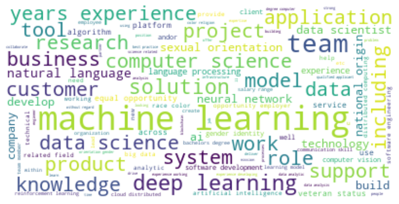

Figure 1: Word Cloud of the Key words in job descriptions

## 2 Data Description

- This dataset is the outcome of a web-crawling exercise aimed at identifying employment opportunities that could potentially interest DSAN students.
- There are roughly 85 searches, each yielding up to 10 job postings, for a total of around 850 jobs, which are currently active online, as of 04/14/2023 .
- The postings were obtained using the following search query terms:
  - [“data scientist”,“data analyst”,“neural networks”,“big data and cloud computing”,“machine learning”, ‘reinforcement learning’,‘deep learning’, “time series”,“block chain”,“natural language processing”]
- The searches are divided into two categories: nationwide and local searches for the United States as a whole and DC, respectively. It is worth noting that these searches are not mutually exclusive, and the files may contain duplicate job postings. These duplicates should be removed during the cleaning process.
- Furthermore, the DC search result extend outside of the specified search area. However, they likely contain a higher sampling of jobs in the DC area.
- The search results are stored in multiple JSON files, with the file name representing the search term. with each file containing the results of a single search

## 3 Data Visualization

### 3.1 An General Overview

**The Top 10 Hiring Companies**

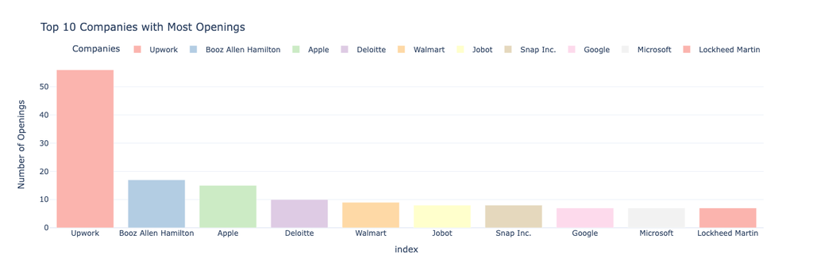

Figure 2:The top 10 hiring companies

**The distribution of Job Categories**

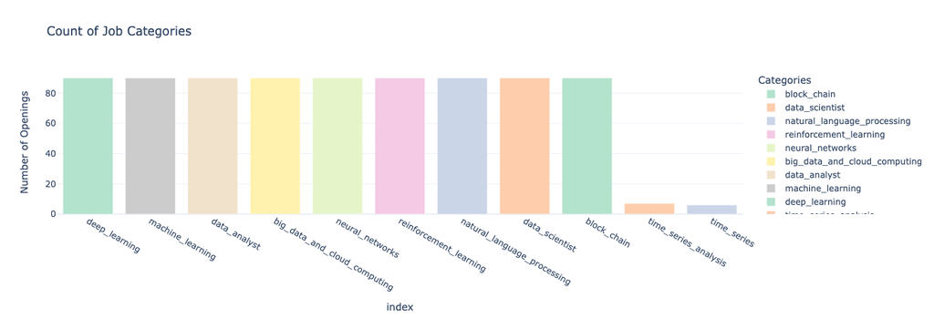

Figure 3: Avalible Jobs by categories

### 3.2 How are these companies paying and which categories their job belong to

[figure not shown]

Figure 4: The Sankey Plot of Top 5 Company with Most Job Posting (Hover and Drag)

The Sankey plot reveals that the majority of job postings from the top five companies (Upwarok, Apple, Booz Allen Hamilton, Deloitte and Walmart) opt to withhold salary details. A significant portion of these undisclosed roles are related to Neural Networks. Moreover, the chart highlights that Blockchain-related roles command higher compensation, a trend that aligns with industry expectations.

### 3.3 Most Job Listed by Location

[figure not shown]

Figure 5: Bubble plot of the total avalible job in each State and percentage of job categories (Hover and Drag)

As of 04/14/2023, the majority of available data-related jobs on the market are not location-specific, with 236 jobs available for remote work. California comes in second with 131 available jobs. It is important to note this trend towards remote work as it offers more flexibility for job seekers, especially during times of economic uncertainty.

### 3.4 Which Job Recurring Platform to Choose

**Top 5 Job Posting Platform**

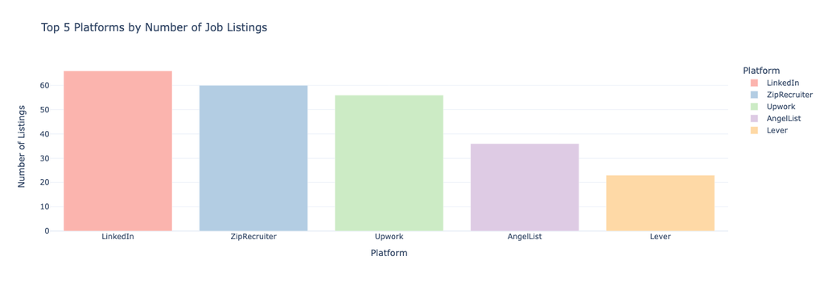

Figure 6: The top 5 job posting platform

**The change of Frequency in Job posting**

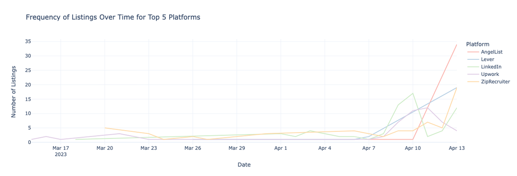

Figure 7: The Frequency of each plaform posting jobs

The plot indicates that LinkedIn (66 posts) remains the most popular job posting platform for companies actively looking to hire, followed by ZipRecruiter (60) and Upwork (56). Therefore, our DSAN students should consider these platforms when looking for a job in the data-related field.